# AESO EMMO Documentation

[Malcolm MacRae](http://ca.linkedin.com/in/malcolmmacrae/)

Saturday, September 13, 2014

## Background

The [Alberta Electric System Operator](http://www.aeso.ca) (AESO) is responsible for responsible for the safe, reliable and economic planning and operation of the Alberta Interconnected Electric System. This operation includes dispatching generation to serve system demand for electricity.

Because electricity cannot be stored on an industrial scale, generation must be dispatched in real-time to meet system demand. Generation is provided by assets across Alberta. Each asset can divide its generation capacity in each hourly interval into up to seven offer blocks. For each offer block, the unit operator specifies a price at which they will supply a specific volume of energy to the system. Each generation asset must offer its total generation capacity at prices between $0 and $999.99/MWh.

The AESO system controller sorts the offer blocks in ascending order of price to create the energy-market merit order (EMMO). The EMMO determines the order in which generation assets are dispatched to run. Generation assets are dispatched in ascending order by offer price until total dispatched generation equals system demand. The highest priced offer block that was dispatched to run sets the system marginal price (SMP). The duration-weighted average of SMP over each hourly interval sets the pool price.

More information about the AESO and the Alberta electricity market is available in the [2013 Annual Market Statistics report](http://www.aeso.ca/downloads/2013_Annual_Market_Statistics.pdf).

## Application Documentation

This [Shiny application](https://mmacrae.shinyapps.io/emmo/) plots a visualization of the AESO EMMO and the pool price for a specified hourly interval. The user specifies the date using a drop-down interface, and specifies the hourly interval using a slider. Hourly intervals are identified by hour ending (HE): the period between 12:00 am and 1:00 am corresponds to HE 01; the period between 1:00 am and 2:00 am, to HE 02; and so on. Once the user has specified the hourly interval, he or she must press the “Submit” button to update the visualization.

Once the user has specified an hourly interval, the application accesses historical data from the AESO [Energy Trading System](http://ets.aeso.ca) (ETS). This data is drawn from two distinct reports: EMMO data is pulled from the “Merit Order Snapshot - Energy” report; pool price data is pulled from the “Actual Forecast” report. Note that EMMO data is unavailable for hourly intervals more recent than 60 days prior to the current date. This delay was intentionally implemented to reflect the potential sensitivity of market information in the report.

Note that this application archives AESO reports on the server after they are accessed for the first time. This archiving process speeds access to the data; however, when a date is accessed for the first time, there may be a short delay while the data is loaded from the AESO website. In testing, this delay did not exceed 30 seconds. Please be patient during this delay.

The purpose of this application is to convey historical information about price sensitivity to load. In some hourly intervals (e.g. 11-Jul-2014 HE 16), pool price was stable: a small increase in load would have moderately increased pool price, while a small decrease in load would have moderately decreased pool price.

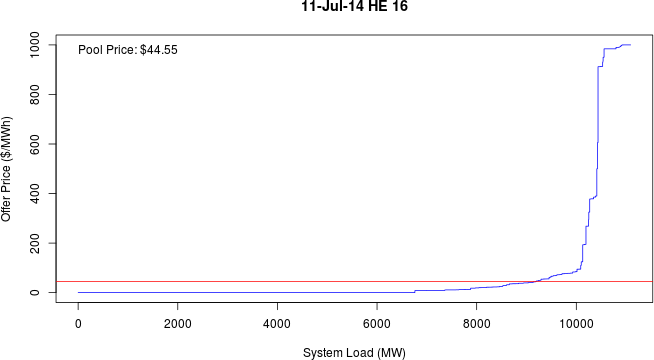

In other hourly intervals (e.g. 13-Jul-2014 HE 16), pool price was extremely volatile: a small decrease in load would have decreased pool price by hundreds of dollars, while a small increase would increased pool price by hundreds of dollars.

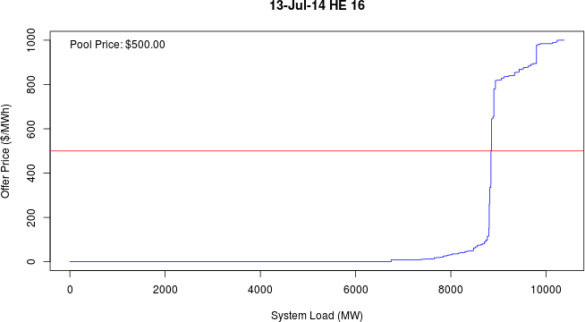